# Crops gone wild: evolution of weeds and invasives from domesticated ancestors - Ellstrand - 2010 - Evolutionary Applications - Wiley Online Library

[Evolutionary Applications](https://onlinelibrary.wiley.com/journal/17524571)

[Volume 3, Issue 5-6](https://onlinelibrary.wiley.com/toc/17524571/2010/3/5-6) p. 494-504

[figure not shown]

Open Access

# Crops gone wild: evolution of weeds and invasives from domesticated ancestors

[Norman C. Ellstrand](https://onlinelibrary.wiley.com/action/doSearch?ContribAuthorRaw=Ellstrand%2C+Norman+C),

[Sylvia M. Heredia](https://onlinelibrary.wiley.com/action/doSearch?ContribAuthorRaw=Heredia%2C+Sylvia+M),

[Janet A. Leak-Garcia](https://onlinelibrary.wiley.com/action/doSearch?ContribAuthorRaw=Leak-Garcia%2C+Janet+A),

[Joanne M. Heraty](https://onlinelibrary.wiley.com/action/doSearch?ContribAuthorRaw=Heraty%2C+Joanne+M),

[Jutta C. Burger](https://onlinelibrary.wiley.com/action/doSearch?ContribAuthorRaw=Burger%2C+Jutta+C),

[Li Yao](https://onlinelibrary.wiley.com/action/doSearch?ContribAuthorRaw=Yao%2C+Li),

[Sahar Nohzadeh-Malakshah](https://onlinelibrary.wiley.com/action/doSearch?ContribAuthorRaw=Nohzadeh-Malakshah%2C+Sahar),

[Caroline E. Ridley](https://onlinelibrary.wiley.com/action/doSearch?ContribAuthorRaw=Ridley%2C+Caroline+E),

First published: 27 August 2010

https://doi.org/10.1111/j.1752-4571.2010.00140.x

Citations: 125

Norman C. Ellstrand, Department of Botany & Plant Sciences and Center for Conservation Biology, University of California, Riverside, CA 92521, USA. Tel.: 1-951-827-4194; fax: 1-951-827-4437; e-mail: ellstrand@ucr.edu

## Abstract

The evolution of problematic plants, both weeds and invasives, is a topic of increasing interest. Plants that have evolved from domesticated ancestors have certain advantages for study. Because of their economic importance, domesticated plants are generally well-characterized and readily available for ecogenetic comparison with their wild descendants. Thus, the evolutionary history of crop descendants has the potential to be reconstructed in some detail. Furthermore, growing crop progenitors with their problematic descendants in a common environment allows for the identification of significant evolutionary differences that correlate with weediness or invasiveness. We sought well-established examples of invasives and weeds for which genetic and/or ethnobotanical evidence has confirmed their evolution from domesticates. We found surprisingly few cases, only 13. We examine our list for generalizations and then some selected cases to reveal how plant pests have evolved from domesticates. Despite their potential utility, crop descendants remain underexploited for evolutionary study. Promising evolutionary research opportunities for these systems are abundant and worthy of pursuit.

## Introduction

Since the advent of agriculture humans have encountered plants that have frustrated their goal to manage their environment. Today, we call the plant pests that interfere with agriculture ‘weeds’. In the last few centuries, humans have taken an increasing interest in preserving and otherwise maintaining the biodiversity of more ‘natural’ [i.e., ‘less managed’ (Kaus and Gómez Pompa 1992)] communities. Here, too, plant pests frustrate human intentions. In such situations, these plants are called ‘invasives’. Weeds and invasives are problematic plants at ends of a continuum of how intensively humans manage an ecosystem, with manicured lawns and cultivated croplands at one end, through forest plantations and rangelands, to natural, deliberately lightly managed, areas at the other end. Thus, the distinction between weeds and invasives, though often clear, is occasionally fuzzy or arbitrary.

Some plants can become weeds and/or invasives with the appropriate ecological opportunity (e.g., colonizing a region where their primary predator is absent) and without any genetic change. But an increasing body of research has revealed that some plants have evolved to become pests. Following the publication of the book, *The Genetics of Colonizing Species* (Baker and Stebbins 1965), evolutionary biologists began to focus on how weeds might evolve (e.g., Baker 1974; de Wet and Harlan 1975; Barrett 1983). The idea of evolution as a potential route to invasiveness has become rapidly accepted in the last two decades, not only for plants, but also for animals and microbes (Blossey and Nötzold 1995; Ellstrand and Schierenbeck 2000; Arnold 2006; Novak 2007; Prentis et al. 2008; Schierenbeck and Ellstrand 2009).

With the goal of understanding whether and how weediness and invasiveness evolve, empirical studies are accumulating that compare problematic lineages with their putative ancestral populations, in plants as well as other organisms (Bossdorf et al. 2005; Dlugosch and Parker 2008a). Some of these studies compare genetic marker variation, often identifying changes in diversity and population genetic structure. Other descriptive studies compare phenotypic or ecological differences (including fitness correlates or biotic interactions) of the invasive or weed and those of putative source populations (Bossdorf et al. 2005; Dlugosch and Parker 2008a; Keller et al. 2009). The latter can suggest evolutionary changes, but ‘common garden’ experiments (e.g., Barrett 1983; Brodersen et al. 2008; Dlugosch and Parker 2008b) in both the invaded and the native range are often necessary to demonstrate genetically-based phenotypic or ecological differences between problematic organisms and their presumed progenitors (Hierro et al. 2005; Moloney et al. 2009).

Common garden studies have revealed adaptive evolution in both weeds and invasives. A classical case is that of a variety of barnyard grass [*Echinochloa crus-galli* var. *oryzicola* (L.) P. Beauv.], a noxious weed that has evolved to mimic domesticated rice (*Oryza sativa* L.) (Barrett 1983). Barrett (1983) grew seedlings of *E. crus-galli* var. *oryzicola*, its progenitor, *E. crus-galli* var. *crus-galli*, and *O. sativa* in a common garden experiment measuring numerous morphological characters. Multivariate analysis of 15 quantitative characters revealed that, in their vegetative phase, rice and its weedy mimic are not significantly different morphologically from each other, despite being in different genera. However, both differed significantly from *E. crus-galli* var. *crus-galli* (see Figs 1 and 2 in Barrett 1983). Morphological crop mimicry is an adaptation that is the result of continued selection by visually-based human weeding. Indeed, barnyard grass individuals in Japanese rice fields that most closely resemble cultivated rice plants morphologically are less likely to be removed from rice fields by hand-weeding (Ehara and Abe 1950). Apparently, thousands of years of hand-weeding rice selected for a crop mimic that is almost vegetatively indistinguishable from rice.

Similar studies have been conducted for invasives. In a common garden experiment conducted in California, Dlugosch and Parker (2008b) compared invasive California populations of the shrub Canary Islands St. John’s wort (*Hypericum canariense* L.) with the native populations of that species, including the genetically-determined precise source population (Tenerife of the Canary Islands). They found that California populations had evolved an increased growth rate relative to the source population. They also found a diversification of flowering phenology of the California plants that correlated with their latitudinal origins. Such apparently adaptive evolutionary changes are not uncommon, although some authors caution that alternative explanations (e.g., climate matching by populations with multiple geographic origins) can account equally well for the appearance of adaptation (Colautti et al. 2009). Only a handful of experimental studies report no evidence for adaptive evolution in invasives relative to their putative source populations (Brodersen et al. 2008).

The example of Dlugosch and Parker (2008b) is exceptional for invasives in that the progenitor population was precisely identified, allowing for the appropriate experimental comparison of progenitor and derived genotypes. But most often detailed information about source populations is, at best, lacking or at worst, complicated by an unknowable number of multiple introductions to multiple locations over decades with little knowledge about the time and place of initial invasion.

## Crops gone wild

A subset of weeds and invasives has evolved from domesticated ancestors, presenting certain advantages for study. We note that weeds and invasives can evolve from domesticate plants by two different pathways (Fig. 1). Some, like California’s weedy rye (Burger et al. 2006) are directly descended from a crop (endoferal ancestry, *sensu*Gressel 2005a), though not all endoferal plant pests necessarily arise via evolutionary change. Other problematic plants, such as Europe’s weed beet (Mücher et al. 2000; van Dijk 2004), are descended from hybrids between a crop and another, usually wild, taxon (exoferal ancestry, *sensu*Gressel 2005a). Knowledge about crop ancestors can illuminate the evolutionary origins of these problematic plants.

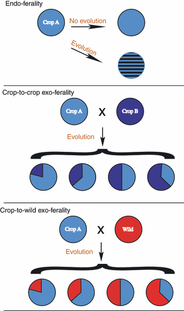

**Figure 1**

Pathways from domesticated plant to problem plant. Pest plants directly descended from domesticated plants (‘endoferal’*sensu*Gressel 2005a) can occur with or without evolutionary change. Plants that are the result of hybridization between a domesticated taxon and another taxon (‘exoferal’*sensu*Gressel 2005a) are necessarily evolutionarily different than their crop progenitor(s).

Because of their economic importance, domesticated plants are often extraordinarily well-studied and well-characterized; many are among the best studied plants. Consider this dramatic illustration: Of the hundreds of thousands of described plant species, roughly 1% are domesticated, but of the eight completely sequenced plant genomes, five belong to domesticated plants (NIH Plant Genomes Website http://www.ncbi.nlm.nih.gov/genomes/PLANTS/PlantList.html). Likewise, domesticated species are attractive for many evolutionary biologists. Charles Darwin’s *The Variation of Animals and Plants under Domestication* (Darwin 1868) was published less than a decade after his *On the Origin of Species by Means of Natural Selection* (Darwin 1859).

Most domesticated species are easily available for experimental and descriptive genetic comparison with their wild descendants. Thus, the history of crop descendants can often be reconstructed in some detail. For recently appearing weedy or invasive lineages, historic ethnobotanical information, confirmed by genetic data, can assign their geographic origin to a limited region. Similar information can sometimes be employed to determine which crop subspecies or varieties might have been involved in the origin of the troublesome lineage. Furthermore, domesticated plants are selected to be grown easily. For example, annual crop seeds typically exhibit no dormancy (Gepts 2004). This tractability can facilitate common garden experiments to identify significant evolutionary changes that correlate with weediness or invasiveness.

Despite these apparent advantages as well as a recent major treatment on crop ferality (Gressel 2005b), plants with domesticated ancestors remain a largely under-appreciated resource for studying how problem plants evolve. Our original motivation was to understand how natural selection works on the descendants of domesticated species so that they are able to become weedy or invasive. We were hoping to review the literature and accumulate a large number of examples to determine sweeping evolutionary generalizations such as whether natural selection results in, for example, the evolution of locally adaptation, of increased competitive ability, or of better dispersal. Below we identify the best studied systems, those invasive and weedy plants that have been genetically confirmed as descendants of domesticates. We found enough examples to identify some potential trends, but too few to make the broad generalizations that we had hoped for. Following our general review, we chose a few examples that provide some insights into the work that needs to be done on systems such as these. In particular, in our discussion, we look to the future. We identify plant pests that are worthy of more evolutionary scrutiny. We also consider how information from already characterized crop traits might illuminate which and how genes evolve along the route to pest status. Finally, we discuss a number of research questions in evolutionary biology that might be fruitfully pursued in these study systems.

## Plant pests descended from domesticates

We sought cases that demonstrate the evolution of invasiveness and/or weediness in plants with domesticated ancestors. We concentrated on finding the most convincing examples supported by the literature. We used four criteria for choosing our examples:

**1** We considered only cases involving ancestors that are well-domesticated taxa. Here, we define well-domesticated taxa as those that have been intentionally cultivated (and thus under intentional or unintentional selection) for at least 1000 years. This initial filter limits the potential number of cases to several hundred species (Smartt and Simmonds 1995) while eliminating most ornamentals, timber trees, and forage grasses. Compared to highly-domesticated plants that are well-differentiated from their wild ancestors, weakly-domesticated taxa are genetically so close to their wild ancestors that it would be almost impossible to determine whether their problematic descendants from have undergone any significant evolutionary change. To illustrate, *Lantana camara* is a plant famous in the nursery trade for escaping cultivation to become a globally significant invasive (Sharma et al. 2005). But it is not clear that the either the horticultural varieties of *L. camara* or their invasive descendants are substantially genetically different from the original wild *L. camara* populations that are the original ancestors to both.

We started out search by examining the examples in Gressel’s (2005b) edited *tour de force* on crop ferality. Likewise, Andersson and de Vicente’s (2010) book on crops and their wild relatives provides detailed information on what is known about feral, weedy, and invasive lineages that have emerged from the world’s most important crop species. Some other examples came from prior treatments that focused on exoferality (e.g., Schierenbeck and Ellstrand 2009 and references therein).

**2** We required genetic or historical evidence that the problematic lineage has evolved from a domesticated taxon. Thus, we excluded from our list plant pests that are known to have well-domesticated ancestors but for which no evidence of evolutionary change has yet been reported (e.g., invasive strawberry guava, Lowe et al. 2000).

Likewise, we excluded problematic plants that may be descended from a crop but could also be descended from a close wild relative of the crop. Consider the case of wild sunflowers (*Helianthus annuus*) that are a substantial weed and/or invasive problem in their native continent of North America as well as in parts of Europe (Bervillé et al. 2005). While they are the same species as cultivated sunflower, it has not yet been established whether any of the *H. annuus* pest populations are descended from the crop or if they are simply descended from the North American wild populations that were the progenitor of the crop. Interestingly, such research on wild sunflowers is reported to be underway (Bervillé et al. 2005). But at the moment, we cannot include such plants in our analysis.

Generally, we treated genetic evidence for a history intertaxon hybridization (exoferality) as *ipso facto* evidence that the lineage is genetically different from its crop progenitor.

**3** After filtering our list through the first two criteria, we asked whether evidence existed that the feral lineage is indeed problematic. For example, many ornamental crops escape from cultivation and persist (Kowarik 2005), but only a few become problematic. In most cases, the primary literature was sufficient to answer the question [e.g., de Wet (1995) characterizes weedy finger millet as ‘obnoxious’]. But if the primary literature simply described a feral lineage as a ‘weed of agriculture’, we tried to assess its significance elsewhere, such as a major weed and/or invasive compendium (e.g., Holm et al. 1977, 1997) or official listing as a weed or invasive by a national or regional authority according to where the lineage has been reported. For example, Bagavathiannan et al. (2010) report that feral alfalfa in Canada is evolutionarily derived from the crop, but a search of Agriculture and Agri-Food Canada’s website (http://www.agr.gc.ca/) revealed that that species is not a significant pest plant in that country.

**4** Finally, we required evidence that the lineage is more problematic than its crop progenitor (in the case of endoferals) or each of its progenitors (in the case of exoferals), that is, that it actually evolved to become a pest. We avoid cases in which a wild invasive taxon has picked up a few crop alleles via hybridization on its invasive spree without a relevant evolutionary change to increased invasiveness.

We found 13 examples of plant pest lineages are descended from crop progenitors. These are enumerated in Table 1. Ten are primarily noxious weeds of agriculture, one is an invader of nonmanaged ecosystems, and the remaining two are both weedy and invasive. Six have an endoferal ancestry; six are descended from hybrids between a domesticated taxon and a wild relative. In the remaining case, the plant pest lineage is descended from hybrids between two cultivated taxa.

Table 1. Invasives (I) or weeds (W) determined to have evolved from domesticated plants.

|  | Common name of plant pest | Progenitor(s) Type of ferality | Source location of crop descendant studied | Key evolved traits relative to crop ancestor | Habit | Citations |
| --- | --- | --- | --- | --- | --- | --- |
| I | Artichoke thistle (in part) | Artichoke (*Cynara cardunculus* var. *scolymus*)* Endoferal | California, USA | Development of spininess, smaller more numerous heads, leaves deeply dissected, delayed and extended flowering period | Perennial herb | Leak-Garcia (2009) |
| W | Semi-wild wheat | Bread wheat (*Triticum aestivum*)* Endoferal | Tibet, China | Easily broken rachis which facilitates shattering | Annual grass | Sun et al. (1998); Ayal and Levy (2005) |
| W | Weedy finger millet | Finger millet (*Eleusine coracana* subsp. *coracana*)* × wild finger millet (*Eleusine coracana* subsp. *africana*) Exoferal | Africa | Disarticulating spikelets | Annual grass | Hilu et al. (1978);. de Wet et al. (1984); de Wet (1995) |
| W | Johnsongrass | Grain sorghum (*Sorghum bicolor*)* × Johnsongrass (*S. halepense*) Exoferal | Nebraska and Texas, USA | Perennial, shattering, rhizomatous | Perennial grass | Morrell et al. (2005) |
| W | Columbus grass | Grain sorghum (*Sorghum bicolor*)* × *S. propinquum* Exoferal | ‘Diverse geographic origins’ | Perennial, shattering, rhizomatous | Perennial grass | Paterson et al. (1995) |
| W | Forrageiro | Radish (*Raphanus sativus*)* Endoferal | Rio Grande do Sul, Brazil | Resistance to ALS-inhibiting herbicides | Annual or biennial forb | Snow and Campbell (2005) |
| I/W | California wild radish | Radish (*Raphanus sativus*)* × Jointed charlock (*R. raphanistrum*) Exoferal | California, USA | Earlier bolting, earlier flowering, increased flower number, unexpanded hypocotyl, increased fruit number, increased seed number | Annual or biennial forb | Hegde et al. (2006) Ridley et al. (2008); Ridley and Ellstrand (2009) |
| W | Weedy rice | Rice (*Oryza sativa japonica*)* Endoferal | Liaoning, China | Shattering | Annual grass | Cao et al. (2006) |
| W | ‘Blackhull’ weedy rice | Rice (*Oryza sativa indica*)* Endoferal | Southeastern USA | Seed dormancy, shattering | Annual grass | Londo and Schaal (2007) |
| W | Weedy rice | Rice (*Oryza sativa japonica*)* × Rice (*O. s. indica*)* Exo-endoferal (feral lineage descended from hybrids between two crops) | Bhutan | Seed dormancy, shattering | Annual grass | Ishikawa et al. (2005) |
| W | ‘Strawhull’ weedy rice | Rice (*Oryza sativa indica*)* × Brownbeard rice (*O. rufipogon*) Exoferal | Southeastern USA | Seed dormancy, shattering | Annual grass | Londo and Schaal (2007) |
| I/W | Weedy rye, feral rye | Rye (*Secale cereale*)* Endoferal | California and Washington, USA | Shattering, smaller seed, delayed flowering | Annual grass | Suneson et al. (1969); Burger et al. (2006, 2007) |
| W | Weed beet | Sugarbeet (*Beta vulgaris* subsp. *vulgaris*)* × Sea beet (*B. v. maritima*) Exoferal | France, Germany, Italy | Shift to annual from biennial habit, woody root | Annual forb | Mücher et al. (2000); van Dijk (2004) |

- *Domesticated plant.

Two of the studies contributing to our list found both a crop origin and a noncrop origin for what has been considered to be a single taxon; that is, some, but not all, of the populations studied had crop ancestors. With regards to weedy rice in the United States, Londo and Schaal (2007) found that most of the accessions genetically analyzed and compared with an array of putative ancestors were either descended from hybrids (mostly ‘strawhull’ weedy rice) or from the crop (mostly ‘blackhull’ weedy rice). But a single accession from California appeared to be descended directly from the wild ancestor *O. rufipogon.* In the similar study of wild artichoke thistle (*Cynara cardunculus* L.) in California (Leak-Garcia 2009), of the 12 wild populations analyzed, four were found to have domesticated ancestry and eight were found to be descendants of Old World wild artichoke thistle.

The list in Table 1 is diverse. The plants are annuals and perennials whose seed and pollen are dispersed in a variety of ways. Cultivated progenitors include both agronomic and horticultural crops. Given the importance of the grass family for human sustenance, it is not surprising that most of the examples are from that family.

A few generalizations are apparent. With the exceptions of rice and wheat with endoferal ancestry, all other cases involve at least one parent that is predominantly outcrossing; in most of the cases at least one parent is self-incompatible. It is certainly possible that outcrossing could facilitate the recombination of genetic diversity between previously isolated lines, creating a burst of variation that can generate an array of phenotypes for a selective substrate (Ellstrand and Schierenbeck 2000; Schierenbeck and Ellstrand 2009). Whether this generalization will hold up as more systems are studied remains to be seen.

Also, many of the reported evolutionary changes represent de-domestication, the evolutionary loss of traits accumulated under domestication (Gressel 2005a). Nine of our examples show an evolutionary shift to readily dispersed seeds or fruits. Typically, agronomic crops that are grown for their seeds have evolved under human selection to be ‘nonshattering;’ that is, the infructescence or fruit holds seeds on the plant until harvest (Gepts 2004). The wild ancestors of those crops have the ‘shattering’ trait for dispersal. So, too, do more than half of our examples, indicating the evolutionary reversal of this trait in the successful derived populations. Three of our examples display the evolution of increased seed dormancy relative to their crop ancestors. Some dormancy in the wild is the rule for monocarpic plants; it has long been interpreted as an evolutionary ‘bet-hedging’ strategy by plant evolutionary ecologists (Venable 2007). As noted above, domesticated annual crops typically have no dormancy, an anthropogenic adaptation that permits quick and uniform germination when sown (Gepts 2004).

In at least one case, the key evolutionary change from a domesticated plant to a pest did not involve the evolutionary reversal of de-domestication. Cultivated radish (*Raphanus sativus* L.) in southern Brazil has evolved resistance to ALS-inhibiting herbicides, the herbicides of choice in that region for no-till agriculture (Snow and Campbell 2005). The resulting lineage called ‘forrageiro’, is now a weed of both winter and summer crops. That trait is not present either in the crop or in its progenitors; thus, its evolution is not a case of de-domestication.

In contrast with the examples of divergence from domesticated ancestors discussed above, in some of our cases certain domesticated traits are retained in the feral lineages. Those traits have not evolved because they presumably provide an evolutionary advantage. In particular, several of the cases in Table 1 are successful because they retained traits making them functional crop mimics. Weedy rice, weedy beet, weedy rye, and semi-wild wheat are hard to control because until they flower, they are morphologically hard to distinguish from their relatives. Thus, their survival is enhanced under hand-weeding.

One of the two most significant generalizations is that the list is short. As we worked our way through the 25 contributed chapters of *Crop Ferality and Volunteerism* (Gressel 2005b), we were surprised that many of the treatments of feral plants offered only agronomic and ecological detail, but very little insight into whether they had evolved from their cultivated ancestors. We contend that the other significant generalization is that there is much to learn from these systems. With few exceptions, our list is simply a recounting of studies that combine data from genetic markers with ethnobotanical history to establish that problem plants evolved from domesticates. Even data regarding the traits that make these plants problematic are largely superficial.

However, we found three systems worthy of deeper discussion. First, we highlight the evolution of weedy rice because it illustrates how what is often perceived as a single problematic lineage is, in fact, a polyphyletic set of lineages with a diversity of evolutionary pathways that capture the breadth of how plant pests evolve from crop ancestors. In contrast the monophyletic story of endoferal weedy rye has been shown to have undergone both rapid evolutionary divergence from its progenitor as well as regional evolutionary diversification in considerably less than a century. We conclude with the curious case of California wild radish, an exoferal derivative of two species that spontaneously hybridize throughout the world; interestingly, that hybridization has yielded a problematic lineage in only one region.

## Three examples of the evolution of problematic plants from domesticated ancestors

### Weedy rice in China, the United States, and Bhutan

Native to Asia, cultivated rice (*Oryza sativa japonica* and *O. sativa indica*) is the world’s most important food crop. Weedy rice (*O. sativa* f. *spontanea*), also known as ‘red rice’, has been an important weed of cultivated rice worldwide for hundreds of years (Holm et al. 1997). Vegetatively, weedy rice is a crop mimic (Valverde 2005), but its infructescence shatters, and its seeds typically exhibit some dormancy. When it co-occurs with rice, the crop suffers depressed yields, and, when co-harvested, the seeds of the weed degrade the quality of the harvested grain. Because it is the same species as cultivated rice, with similar morphology and physiology, it is very difficult to control by both weeding and chemical means.

The evolutionary origin of weedy rice has been controversial. Its putative ancestry includes various hypotheses: that is a wild relative of rice that has evolved crop mimicry, that it is descended directly from cultivated rice, or that it is an exoferal lineage descended from hybrids between a wild taxon and cultivated rice (Vaughan et al. 2005).

Three recent genetic studies of weedy rice have addressed its evolutionary origins. After decades of successful suppression, in the last decade weedy rice has emerged as a problem in the rice fields of certain regions of China (Cao et al. 2006). Motivated by the resurgence of this pest, Cao et al. (2006) compared 20 DNA based SSR markers from 30 populations of weedy rice collected from China’s Liaoning province with those of wild *O. rufipogon* as well as selected rice varieties from the two major cultivar groups, *japonica* and *indica.* Statistical analysis of the genetic data revealed the local Liaoning cultivar (a *japonica* type) clustered within the array of weedy rice populations. Another major Chinese *japonica* cultivar showed much less affinity. The wild *O. rufipogon* and domesticated *indica* types were even more distantly related from the Liaoning weeds. The authors conclude ‘weedy rice populations from Liaoning most probably originated from Liaoning rice varieties by mutation and intervarietal hybrids’. We agree that an intertaxon hybrid origin for Liaoning weedy populations is unlikely; if hybridization had occurred, it is likely that some *O. rufipogon* alleles would have been retained in the weedy lineages in the short time that they have been problematic.

Weedy rice has been a problematic weed of rice in the southeastern United States for well over a century (Gealy 2005). To identify the origins of this weed Londo and Schaal (2007) took a similar approach to Cao et al. (2006), genetically analyzing 29 different United States weedy rice accessions from six different states to ‘cover the entire range of US rice culture’. For comparison, they chose 113 accessions representing a variety of *indica* and *japonica* cultivars, *O. rufipogon*, and other wild relatives. They used data from both sequencing a nuclear pseudo-gene (p-VATP) and 21 DNA-based microsatellite loci. The authors used the program STRUCTURE (Pritchard et al. 2000) to infer the origin of the weedy rice accessions and their possible history of hybridization. STRUCTURE uses a Bayesian approach to examine the relationships of multilocus genotypes of individuals by differences in allele frequency and the nature of linkage disequilibrium. In the United States, the vast majority of cultivars are *japonica* types, but STRUCTURE analysis assigned almost all of the US weedy accessions to two groups unallied with *japonica.* Blackhulled weedy rice and a few other accessions were almost identical to domesticated *O. sativa indica* var. *Aus*; strawhulled weedy rice and a few other accessions were classified with exoferal ancestry involving hybridization of *O. sativa indica* and wild *O. rufipogon.* A single accession appeared to be descended directly from the wild ancestor *O. rufipogon.* Clearly, most of the US weedy rice populations evolved from the cultivated species, but it is also clear that evolution did not occur in the United States. These data as well as other historical data (Gealy 2005) suggest that US weedy rice has an Asian origin.

Yet another pathway for the origin of weedy rice has been described for its populations in Bhutan (Ishikawa et al. 2005). In that country *japonica* rice cultivars predominate in the highlands while *indica* cultivars predominate in the lowlands. Ishikawa et al. (2005) compared lowland cultivars, highland cultivars, and weedy populations with regards to nine isozyme loci, a chloroplast genome deletion, and four microsatellite loci. They found clear genetic differentiation between *japonica* and *indica* cultivars, and at the same time, they found that the weedy populations had genotypes that had both combinations of both *japonica*-specific alleles and *indica*-specific alleles. They report that they did not detect any alleles specific to wild relatives. Thus, their conclusion is that the weedy populations are lineages descended from *japonica x indica* hybrids. When Gressel (2005a) named the different evolutionary pathways to ferality, he did not consider intercultivar hybridization. Following his lead, we call this particular pathway for Bhutanese weedy ricde ‘exo-endoferality’ because it is first a case of endoferality because all ancestors are domesticates, but also ‘exo-’ because intertaxon hybridization is a critical evolutionary step.

All three of the above comprehensive studies present strong evidence for the origin of the vast majority of the weedy rice populations to be from cultivated rice. Interestingly, the data collected reveals a polyphyletic origin for weedy rice. Polyphylesis is now well-known to play a role in the evolution of many invasive lineages (Novak 2007) but it is not clear whether it is the rule for domesticate-derived pests.

For three of the four discovered pathways, involving direct ancestry from *indica* and *japonica,* de-domestication likely occurred via the evolution of (at least) shattering due to either mutation or an epistatic recombination event. The most parsimonious pathway for the remaining exoferal lineage detected by Londo and Schaal (2007) is for *O. rufipogon* to have provided the allele or alleles for shattering.

### Weedy rye in western North America

In terms of area planted, cereal rye (*Secale cereale* L.) is one of the world’s top 10 grain crops. Volunteer rye has occasionally been a serious agricultural weed problem throughout North America for about 100 years. However, by the early 1960s self-sustaining, naturalized weedy rye populations were identified as increasingly problematic as weeds of cultivated lands and invasives of uncultivated lands in the US states of Washington, Oregon, Idaho, and California. As a weed of cultivated rye, it was so bad that ‘farmers … abandoned efforts to grow cultivated rye for human consumption’ (National Research Council 1989). Subsequently, weedy rye has spread elsewhere in the western United States and the Canadian province of British Columbia (Burger and Ellstrand 2005).

Western North American weedy rye was originally thought to be a hybrid derivative of cultivated rye and the wild perennial mountain rye [*S. strictum* (C. Presl) C. Presl.]. However, subsequent genetic analysis of several populations of North American weedy rye with 14 allozyme and three microsatellite loci failed to detect any ancestry from *S. strictum* or any other wild *Secale*. Overall, the weedy populations are more similar to each other than to any one cultivar. Nonetheless, the invasive populations share a single lineage that apparently evolved directly from one or more cultivars of cereal rye (Burger et al. 2006).

Just as in the case of rice, cultivated rye is nonshattering and has little dormancy, while its derivative has evolved dispersal by shattering. De-domestication of the nonshattering trait to shattering likely occurred via mutation or perhaps an epistatic recombination event. Interestingly, in this case, both the crop and the feral populations have little seed dormancy. Other traits such as smaller seed, smaller leaves, thinner culms, and delayed flowering have rapidly evolved in this lineage (roughly 60 generations since original observations of volunteer populations) (Burger et al. 2007). It is not clear whether all of these traits contribute to its evolution as a plant pest, especially its invasiveness outside of agroecosystems. However, evolution of a change in flowering time relative to an ancestor can be a powerful reproductive isolating mechanism. In this case, it might have evolved under selection to frustrate maladaptive gene flow (‘reinforcement’ of isolation) from the crop to the weedy lineage (Levin 1978; see our relevant expanded discussion of evolution of reproductive isolation below).

### Wild radish in far western North America

Cultivated radish (*R. sativus*) is an important vegetable whose root (botanically, the expanded hypocotyl) is consumed worldwide. The wild jointed charlock (*R. raphanistrum* L.; sometimes, confusingly called ‘wild radish’) is a closely related species, separated from the cultigen by a chromosomal translocation and a suite of morphological characters. When the two co-occur in most of the world, spontaneously hybridization occurs to a limited extent, resulting in no more than highly localized hybrid swarms (Snow and Campbell 2005).

In contrast, for almost 100 years, hybridization between the two *Raphanus* taxa in California has been more extensive (Frost 1923; Panetsos and Baker 1967). In the last 50 years, hybrid-derived wild *Raphanus* has invaded coastal plains and disturbed inland valleys along the Pacific edge of North America from the US state of Oregon south through California to the Mexican state of Baja California (Whitson 2006). It has also become a troublesome weed for agronomic crops.

Experimental work on what is now known as ‘California wild radish’ has confirmed it to be a lineage descended from hybrids of *R. sativus* and *R. raphanistrum.*Hegde et al. (2006) compared California wild radish populations with cultivars of *R. sativus* and populations of *R. raphanistrum.* They used 10 allozyme loci as well as common garden experiments to characterize the three types. The allozyme data revealed that California wild radish populations were in Hardy-Weinberg equilibrium; that is, there was no evidence that pure individuals of the parental taxa had persisted in significant frequencies. STRUCTURE analysis of the allozyme dataset confirmed that conclusion. STRUCTURE assigned the cultivated radish to one group and the jointed charlock individuals to another group. The individuals from the California wild radish populations were assigned at various levels of hybrid ancestry involving the first two groups. Multivariate analysis of morphological characters measured in their common garden experiments revealed that the standard phenotype of California wild radish is significantly different from both of its progenitors. Interestingly, its bolting date, flowering date, and hypocotyl width are intermediate to its progenitors; its fruit diameter and fruit length are the same as the cultigen; and its fruit weight transgresses both parents! A subsequent common garden experiment showed that in several, contrasting California environments, the hybrid lineage produced both more fruits per plant and more seeds per plant than either progenitor (Ridley and Ellstrand 2009), including specific source cultivars and *R. raphanistrum* populations as determined from cpDNA analysis (Ridley et al. 2008).

Is there something special about California that permitted this rapid adaptive evolution to proceed in light of the fact that *Raphanus* hybrids elsewhere have proven to be evolutionary deadends? Another common garden experiment has given a tantalizing result. Synthetic, F<sub>4</sub> generation hybrid lineages and their *R. raphanistrum* progenitors were grown in the field in Michigan and California. The hybrid lineages’ fitness was slightly inferior to *R. raphanistrum* in Michigan but in California they exhibited 22% greater survival and 270% greater lifetime fecundity (Campbell et al. 2006; see also Campbell and Snow 2009).

## Avenues for future research

Evolutionary studies on weedy and/or invasive plants that have domesticated ancestors have been useful for detailing the phylogenetic history of such plants. More examples might exist. While accumulating our examples for Table 1, we encountered some cases for which the current evidence is too weak at this time to convincingly support or refute a crop origin for an invasive lineage. These are enumerated in Table 2. Likewise, we encountered examples of domesticated taxa that have become plant pests, but it is not clear whether these have evolved to become pests or are simply ecological opportunists (Table 3). Consider the case of strawberry guava (*Psidium cattleianum* Sabine). The free-living version of this domesticated plant is considered by some to be one of the world’s worst invasive species (Lowe et al. 2000), but no studies have examined whether the invasive strawberry guava populations are substantially genetically different from their domesticated progenitor.

Table 2. Invasives (I) or weeds (W) with too little evidence to determine whether they are descended from domesticated plants.

|  | Common name of plant pest | Possible crop progenitor (s) | Citations |
| --- | --- | --- | --- |
| I | Fennel | Fennel, *Foeniculum vulgare* | Bell et al. (2008) |
| I | Sunflower | Cultivated sunflower, *Helianthus annuus* | Bervillé et al. (2005) |
| I | Jerusalem artichoke | Jerusalem artichoke, *Helianthus tuberosus** | Bervillé et al. (2005); Kowarik (2005) |
| W | Green bristlegrass | Foxtail millet, *Setaria italica* | Darmency (2005) |
| W | Shattercane | Grain sorghum, *Sorghum bicolor* | Ejeta and Grenier (2005) |

Table 3. Invasives (I) or weeds (W) that are descended from domesticated plants but whether they have evolved is not known.

|  | Name of plant pest and its progenitor | Citations |
| --- | --- | --- |
| I | Strawberry guava (*Psidium cattleianum*) | Lowe et al. (2000) |
| I,W | Callery pear (*Pyrus calleryana*) | Culley and Hardiman (2009) |
| I | Arabica coffee (*Coffea arabica*) | Joshi et al. (2009) |
| I | Robusta coffee (*Coffea canephora*) | Joshi et al. (2009) |

The majority of our entries in Table 1 are examples of remarkably rapid evolution, at least six of our problematic lineages evolved in less than a century. The comparison of progenitors and their wild descendants grown in a common environment reveals differences that may account for the success of the latter.

Nonetheless, research on such systems has barely exploited their utility for evolutionary study in comparison with certain other plant pests, such as the large body of integrated ecological, physiological and genetic study employed to understand evolution of invasiveness in North American reed canarygrass (*Phalaris arundinacea* L.) by Molofsky and colleagues (Lavergne and Molofsky 2004) (For some other examples of rapid evolution in invasive plant species see Xu et al. (2010) and references therein). In particular, invasives and weeds descended from domesticated plants are ripe for approaches to tease out the evolutionary pathway to their new lifestyle. How do they differ from their progenitors with respect to their ecological relationships with biotic enemies, that is, herbivores and disease-causing organisms? Are there any differences in their chemical or physical defenses?

Genetic and genomic approaches, often used in concert with ethnobotanical data, have been successful in illuminating the evolution of crops from wild species under domestication (Purugganan and Fuller 2009). These approaches may prove to be equally powerful in investigating evolution in the other direction, the evolution of sustainable feral populations from domesticated species. Let’s consider some of these approaches.

Refined cytogenetic tools for studying chromosomal evolution under domestication have expanded to include not only traditional chromosome banding, but also techniques using fluorescent *in situ* hybridization (FISH) (e.g., Zhang et al. 2002) and genomic *in situ* hybridization (GISH) (e.g., Stace and Bailey 1999). Despite the fact that many major crops are cytogenetically well-characterized, we are not aware of any studies that address whether and how chromosomal evolution has occurred under de-domestication.

Even if a crop species hasn’t had its genome sequenced, it is likely to be well-mapped. Quantitative trait locus (QTL) mapping has proven a powerful way to study the domestication-related genes (Paterson 2002) by examining the co-segregation of a trait with markers to determining the number of loci, their chromosomal location, and their relative influence on the expression of that trait. For example, the first maize ‘domestication gene’, *teosinte branched1* (tb1), was identified by QTL mapping (Doebley et al. 1995). In the same way, crosses between plant pests and their crop progenitors can be made to examine the genetic basis of key ecological traits that correlate with invasive success (Prentis et al. 2008).

Evolutionary genomic approaches have proven particularly fruitful for identifying the genomic and genetic correlates of crop domestication, in particular, potential adaptive changes (e.g., Ross-Ibarra et al. 2007). For domesticated taxa that have had their genome sequenced, such as rice and sorghum, comparative evolutionary eco-genomic approaches with their descendants will be able to provide a sweeping view of what genomic changes have occurred in the evolution of invasives and/or weeds relative to their crop ancestor. As genome sequencing become both less expensive and easier to conduct (http://genome10k.soe.ucsc.edu/), such approaches will become available for more species, but the descendants of domesticated taxa will still have the advantage of centuries of study.

We end with a few intriguing questions based on the simple observation that crops and weeds often have a lot in common ecologically. First, with regard to crops and their weedy derivatives, we note that both grow in exactly the same location, but they are subjected to different selection regimes. How do weedy crop derivatives end up perceiving different selection pressures so that diverge in sympatry? Furthermore, how do they diverge given that they are likely to be swamped by gene flow from the initially more abundant crop? With regards to the latter question, it is clear that reproductive isolating barriers must evolve rapidly, perhaps explaining why our list of examples is short (that is, evolution of sustainable feral populations is difficult). And, at the same time, that would explain why phenological divergence has been noted for all of our examples descended from an outcrossing crop ancestor (artichoke, radish, rye, beet) which would be subject to a rain of cross-compatible pollen, but not for all of those descended from a highly selfing crop ancestor (wheat, finger millet, sorghum, rice) for which relatively short distances should afford reproductive isolation.

Second, both crops and weeds are often selected for a life in a disturbed habitat. Both characteristically grow densely in simple communities or even monocultures. If humans select crops that grow densely in monospecific stands, are those plants only a few allele changes away from becoming invasives or weeds (de Wet and Harlan 1975)? If such is the case, careful and thorough evaluation should accompany the development of new crops designed to answer pressing societal needs, including new bioenergy feedstocks created with the goal of providing a stable domestic energy supply (Barney and DiTomaso 2008).

## Acknowledgements

Our initial manuscript benefited from the ideas of Professor Jeffrey Ross-Ibarra and his Graduate Genetics Group at the University of California at Davis. The authors thank Bao Doan, Baorong Lu, Jeffrey Ross-Ibarra, Allison Snow, and two anonymous reviewers for their ideas and/or insightful contributions to subsequent versions of this manuscript. This work was supported by NSF DEB-0409984 and NRI-CSREES-USDA 2003-35320 grants to N.C.E. as well as a US Environmental Protection Agency (EPA) Science to Achieve Results (STAR) Graduate Fellowship to C.E.R. EPA has not officially endorsed this publication, and the views expressed herein might not reflect the views of EPA.

## Citing Literature

[Volume3, Issue5-6](https://onlinelibrary.wiley.com/toc/17524571/2010/3/5-6)

[Special Issue: Evolution in Agro-Ecosystems](https://onlinelibrary.wiley.com/toc/17524571/2010/3/5-6)

September 2010

Pages 494-504

beta

- Supporting

powered by

[figure not shown]

### Recommended

  [Norman C. Ellstrand](https://onlinelibrary.wiley.com/action/doSearch?ContribAuthorRaw=Ellstrand%2C+Norman+C),

  [J. McNEILL](https://onlinelibrary.wiley.com/action/doSearch?ContribAuthorRaw=McNEILL%2C+J),

  [Weed Research](https://onlinelibrary.wiley.com/journal/13653180)

[back](https://onlinelibrary.wiley.com/doi/10.1111/j.1752-4571.2010.00140.x)

[figure not shown]

1

2

hide